# Forecasting the Supreme Court’s decisions with CARTs (Part 1)

Stefano Galelli

Term 6, 2020

First, we prepare the working environment.

```r
rm(list = ls())   # Clear the environment
# setwd("...")  # Setup the working directory
setwd("~/Documents/SUTD/Term 6/TAE/W8")
```

# 1 Data Preparation

## 1.1 Load the data on the US Supreme Court

```r
supreme <- read.csv("supreme.csv") # We have 623 observations and 20 variables
str(supreme)       # Internal structure of the dataframe
```

```
## 'data.frame':    623 obs. of  20 variables:
##  $ docket : chr  "92-2038" "93-1001" "93-1128" "93-1151" ...
##  $ term   : int  1994 1994 1994 1994 1994 1994 1994 1994 1994 1994 ...
##  $ party_1: chr  "FOOD" "FRANCHIS" "VTAD" "FEC" ...
##  $ party_2: chr  "FARMER" "O" "VETERAN" "PAC" ...
##  $ rehndir: int  1 0 0 1 1 1 1 1 1 0 ...
##  $ stevdir: int  0 0 0 0 0 0 1 1 0 1 ...
##  $ ocondir: int  1 0 0 1 0 1 0 0 1 1 ...
##  $ scaldir: int  1 1 0 1 1 1 1 0 1 9 ...
##  $ kendir : int  1 0 0 1 0 0 1 1 1 0 ...
##  $ soutdir: int  1 0 0 1 0 0 0 0 0 0 ...
##  $ thomdir: int  1 1 0 1 1 1 1 0 1 1 ...
##  $ gindir : int  1 0 0 9 0 0 1 1 0 0 ...
##  $ brydir : int  1 0 0 1 0 0 0 1 0 0 ...
##  $ petit  : chr  "BUSINESS" "OTHER" "OTHER" "OTHER" ...
##  $ respon : chr  "BUSINESS" "OTHER" "OTHER" "OTHER" ...
##  $ circuit: chr  "FED" "11th" "FED" "DC" ...
##  $ unconst: int  0 0 0 0 0 0 0 0 0 0 ...
##  $ lctdir : chr  "liberal" "conser" "liberal" "conser" ...
##  $ issue  : chr  "ECN" "ECN" "CR" "JUD" ...
##  $ result : int  1 0 0 1 0 0 1 1 1 0 ...
```

```r
# head(supreme)    # First part of the dataframe
# summary(supreme) # Summary of the data
```

## 1.2 A few comments on the data

- `docket`: case number
- `term`: year the case was discussed
- `party_1` and `party_2`: parties involved in the case
- `rehndir`, `stevdir`, `ocondir`, `scaldir`, `kendir`, `soutdir`, `thomdir`, `gindir`, `brydir`: direction of the judgement of the 9 judges (i.e., Rehquist, Stevens, O’Connor, Scalia, Kennedy, Souter, Thomor, Ginsburg, Breyen). 0 means liberal, 1 conservative. 9 indicates that the vote is not available for the case
- `petit`: petitioner type
- `respon`: respondant type
- `circuit`: circuit of origin
- `uncost`: binary number indicating if the petitioner argued the practice was unconstitutional
- `lctdir`: lower court direction (liberal or conservative)
- `issue`: area of issue
- `result`: 0 means liberal, 1 conservative

## 1.3 More insights on the data

Let’s now focus on a specific judge, say Stevens. We begin by removing data with no entry from Stevens.

```r
stevens <- subset(supreme[, c("docket", "term", "stevdir", "petit", "respon", "circuit", "unconst", "lctdir", "issue", "result")], supreme$stevdir != 9)
```

Then, we process the output result to affirm or reverse for judge Stevens. This creates a new variable (`$rev`) in the dataframe that takes a value of 1 if Stevens’ decision reverses the lower court decision and 0 if the judge affirms the lower court decision. Note that a similar analysis can be done for the other judges or for the overall case result.

```r
stevens$rev <- as.integer((stevens$lctdir == "conser" & stevens$stevdir == 0) | (stevens$lctdir == "liberal" & stevens$stevdir == 1))
```

The table below gives us some stats about judge Stevens’ decisions. He voted 341 times to reverse the lower court direction and 278 times to affirm it.

```r
table(stevens$rev)
```

```
##
##   0   1
## 278 341
```

## 1.4 Training and testing datasets

Finally, we split the data into training and testing datasets. To this purpose, we use the `caTools` package.

```r
if(!require(caTools)){                          # install or load the package
  install.packages("caTools")
  library(caTools)
}

set.seed(123)                                   # set seed for random sampling
spl <- sample.split(stevens$rev, SplitRatio = 0.7) # We use 70% of the data for training
train <- subset(stevens, spl == TRUE);             # training dataset
test <- subset(stevens, spl == FALSE);             # testing dataset
```

# 2 Modelling exercise (warm up): Logistic regression

Before introducing the Classification and Regression Trees (CARTs), let’s warm up with a simple exercise: predicting justice Stevens’ decisions with Logistic Regression.

```r
m1 <- glm(rev ~ petit + respon + circuit + unconst + issue + lctdir, data = train, family = "binomial")
summary(m1)
```

```
##
## Call:
## glm(formula = rev ~ petit + respon + circuit + unconst + issue +
##     lctdir, family = "binomial", data = train)
##
## Deviance Residuals:
##     Min       1Q   Median       3Q      Max
## -2.3349  -0.9123   0.4116   0.8248   2.3782
##
## Coefficients:
##                 Estimate Std. Error z value Pr(>|z|)
## (Intercept)     15.43916 1355.85951   0.011  0.99091
## petitCITY      -16.93761  720.15793  -0.024  0.98124
## petitDEF         0.59786    0.64254   0.930  0.35213
## petitEE          0.43030    0.72495   0.594  0.55280
## petitER         -1.26346    0.87564  -1.443  0.14905
## petitINDIAN     -0.91308    1.58870  -0.575  0.56547
## petitIP         -1.04352    0.88462  -1.180  0.23815
## petitOF         -0.09806    0.54150  -0.181  0.85630
## petitOTHER      -0.13207    0.36870  -0.358  0.72018
## petitPOL        -0.20375    0.73925  -0.276  0.78284
## petitSTATE      -1.50729    0.75467  -1.997  0.04579 *
## petitUS          0.11688    0.56039   0.209  0.83479
## responCITY      -0.24879    0.86416  -0.288  0.77343
## responDEF       -0.94506    0.65706  -1.438  0.15035
## responEE         0.18979    0.69524   0.273  0.78487
## responER         0.75096    0.94121   0.798  0.42495
## responINDIAN     2.32265    1.04897   2.214  0.02681 *
## responIP        -0.96069    0.79812  -1.204  0.22871
## responOF        -0.87849    0.69502  -1.264  0.20624
## responOTHER      0.01909    0.38023   0.050  0.95995
## responPOL       -0.20746    0.80781  -0.257  0.79732
## responSTATE      0.03776    0.66854   0.056  0.95496
## responUS        -1.27479    0.57609  -2.213  0.02691 *
## circuit11th      0.76732    0.63362   1.211  0.22589
## circuit1st       1.15232    0.88601   1.301  0.19341
## circuit2nd       1.97008    0.74723   2.637  0.00838 **
## circuit3rd      -0.48331    0.72431  -0.667  0.50460
## circuit4th       1.73795    0.70308   2.472  0.01344 *
## circuit5th       1.50984    0.65793   2.295  0.02174 *
```

[output cut: 13 more lines]

```
## issueJUD       -15.13777 1355.85937  -0.011  0.99109
## issuePRIV      -14.06380 1355.85956  -0.010  0.99172
## issueTAX       -15.56614 1355.85954  -0.011  0.99084
## issueUN        -16.21739 1355.85952  -0.012  0.99046
## lctdirliberal   -1.34070    0.30913  -4.337 1.44e-05 ***
## ---
## Signif. codes:  0 '***' 0.001 '**' 0.01 '*' 0.05 '.' 0.1 ' ' 1
##
## (Dispersion parameter for binomial family taken to be 1)
##
##     Null deviance: 597.18  on 433  degrees of freedom
## Residual deviance: 458.50  on 387  degrees of freedom
## AIC: 552.5
##
## Number of Fisher Scoring iterations: 15
```

Let’s now try to make a prediction on the test data. We cannot use the command `p1 <- predict(m1,newdata=test,type="response")`, because `issue` has only one realization of the IR value (Interstate Relations), which is not estimated in the training set. Let’s thus modify the test dataset as follows:

```r
test <- subset(test, test$issue != "IR")
p1 <- predict(m1, newdata = test, type = "response")
```

How does the model perform?

```r
# confusion matrix
table(p1 >= 0.5, test$rev)
```

```
##
##          0  1
##   FALSE 55 36
##   TRUE  27 66
```

So the accuracy is `0.6576087`. Let’s plot the ROC Curve.

```r
if(!require(ROCR)){
  install.packages("ROCR")
  library(ROCR)
}

pred <- prediction(p1, test$rev)
perf <- performance(pred, x.measure = "fpr", measure = "tpr")
performance(pred, measure = "auc")
```

```
## A performance instance
##   'Area under the ROC curve'
```

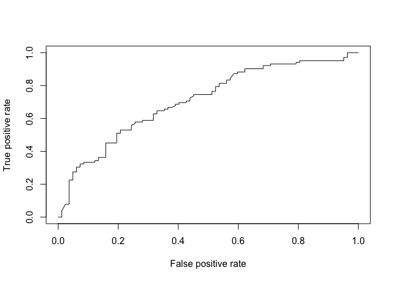

```r
plot(perf)
```

# 3 Classification And Regression Trees (CARTs)

```r
if(!require(rpart)){        # rpart is for CART
  install.packages("rpart")
  library(rpart)
}
```

## 3.1 Building a CART

The command `cart1 <- rpart(rev~petit+respon+circuit+lctdir+issue+unconst,data=train)`, will not work, because `rpart` builds a regression tree by default. So, remember to specify you are working on a classification problem!

```r
library(rpart)
cart1 <- rpart(rev ~ petit + respon + circuit + lctdir + issue + unconst, data = train, method = "class")
# Alternative way of building a classification tree
# cart1 <- rpart(as.factor(rev) ~ petit + respon + circuit + lctdir + issue + unconst, data = train)
```

## 3.2 What’s inside a CART?

The variable `cart1` contains all the information about the tree, with nodes, branches and the corresponding probability associated to each class. To analyze its content, we have a couple of options.

The first is to use the function `print()`: for each node, we know: node number, variable used for splitting, number of observations in the node, loss error in the node, predicted value, and predicted probabilities. Note that the children of node x are numbered 2x and 2x+1. Also, note that a variable might appear many times in the tree.

```r
print(cart1)
```

```
## n= 434
##
## node), split, n, loss, yval, (yprob)
##       * denotes terminal node
##
##   1) root 434 195 1 (0.4493088 0.5506912)
##     2) lctdir=liberal 202  75 0 (0.6287129 0.3712871)
##       4) respon=DEF,IP,POL,STATE,US 59   9 0 (0.8474576 0.1525424) *
##       5) respon=BUSINESS,EE,INDIAN,OF,OTHER 143  66 0 (0.5384615 0.4615385)
##        10) petit=CITY,EE,ER,IP,POL,STATE 33   7 0 (0.7878788 0.2121212) *
##        11) petit=BUSINESS,OF,OTHER,US 110  51 1 (0.4636364 0.5363636)
##          22) circuit=10th,11th,3rd,8th,DC,FED 46  18 0 (0.6086957 0.3913043) *
##          23) circuit=1st,2nd,4th,5th,6th,7th,9th 64  23 1 (0.3593750 0.6406250)
##            46) issue=CP,FA,JUD,UN 22  10 0 (0.5454545 0.4545455)
##              92) petit=OF,OTHER 15   5 0 (0.6666667 0.3333333) *
##              93) petit=BUSINESS,US 7   2 1 (0.2857143 0.7142857) *
##            47) issue=CR,DP,ECN,FED,PRIV,TAX 42  11 1 (0.2619048 0.7380952) *
##     3) lctdir=conser 232  68 1 (0.2931034 0.7068966)
##       6) circuit=10th,11th,2nd,3rd,6th,7th,9th,DC,FED 156  58 1 (0.3717949 0.6282051)
##        12) issue=DP,FA,FED,PRIV,TAX,UN 38  16 0 (0.5789474 0.4210526)
##          24) respon=BUSINESS,DEF,IP,OF,OTHER 22   6 0 (0.7272727 0.2727273) *
##          25) respon=CITY,EE,ER,POL,STATE,US 16   6 1 (0.3750000 0.6250000) *
##        13) issue=AT,CP,CR,ECN,JUD 118  36 1 (0.3050847 0.6949153)
##          26) petit=CITY,INDIAN,IP,OF,STATE,US 13   4 0 (0.6923077 0.3076923) *
##          27) petit=BUSINESS,DEF,EE,ER,OTHER,POL 105  27 1 (0.2571429 0.7428571)
##            54) respon=US 27  13 1 (0.4814815 0.5185185)
##             108) circuit=11th,9th,FED 8   2 0 (0.7500000 0.2500000) *
##             109) circuit=2nd,3rd,6th,7th,DC 19   7 1 (0.3684211 0.6315789) *
##            55) respon=BUSINESS,EE,ER,INDIAN,IP,OF,OTHER,POL,STATE 78  14 1 (0.1794872 0.8205128) *
##       7) circuit=1st,4th,5th,8th 76  10 1 (0.1315789 0.8684211) *
```

The second option we have is to use the function `summary()`.

```r
summary(cart1)
```

[output not shown]

## 3.3 Visualizing a CART’s structure

A fundamental advantage of CARTs is that it possible to visualize their structure. There is a number of packages that can be used to this purpose.

We begin with the default function (available in the `rpart package`)

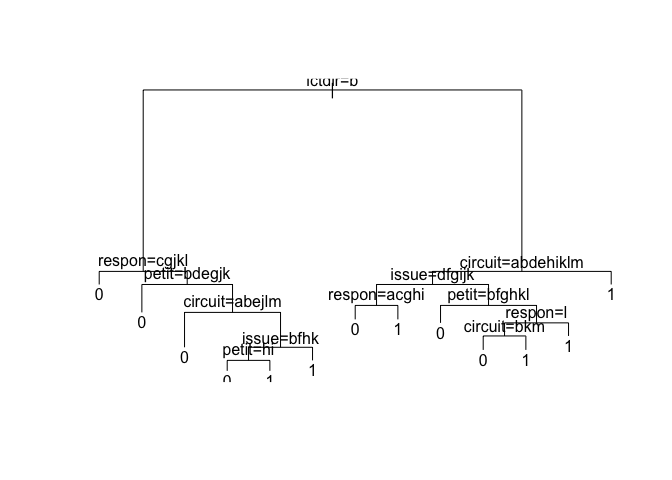

```r
plot(cart1); text(cart1)
```

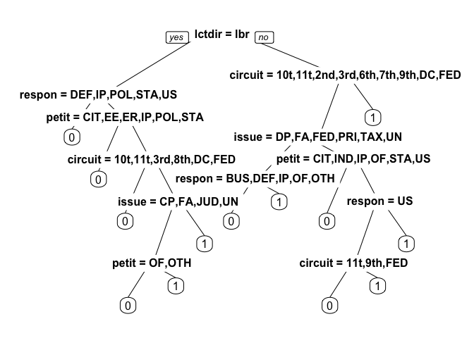

```r
if(!require(rpart.plot)){
  install.packages("rpart.plot")
  library(rpart.plot)
}

prp(cart1)
```

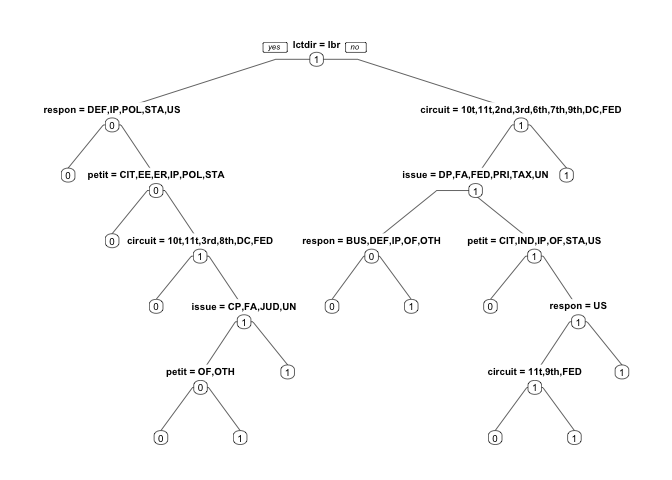

```r
prp(cart1, type = 1) # labels all nodes (not just the leaves)
```

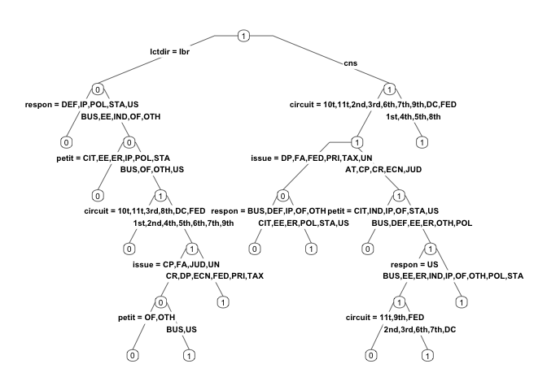

```r
prp(cart1, type = 4) # draws separate labels for left and right directions for all nodes and label nodes
```

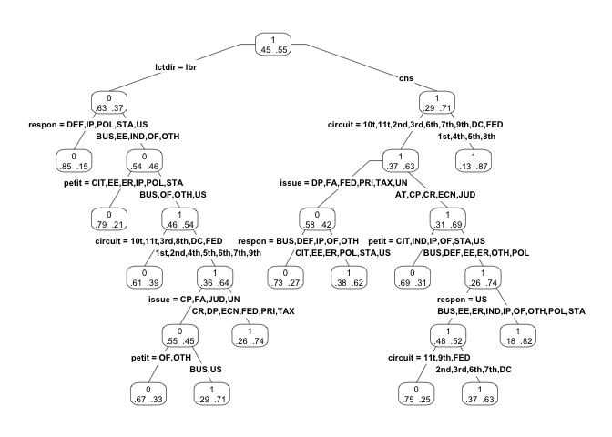

```r
prp(cart1, type = 4, extra = 4) # in addition, this also plots the probability per class of observation
```

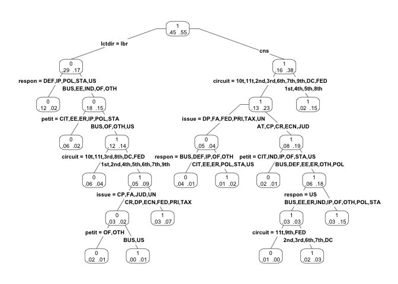

```r
prp(cart1, type = 4, extra = 9) # probablities times fraction of observations at the node (the sum across all leaves is 1)
```

Other visualization options: see an example with the `fancyRpartPlot()` function, which requires `rpart.plot`, `rattle`, and `RColorBrewer`.

[figure not shown]

```r
if(!require(rattle)){
  install.packages("rattle")
  library(rattle)
}

if(!require(RColorBrewer)){
  install.packages("RColorBrewer")
  library(RColorBrewer)
}
fancyRpartPlot(cart1) # Run fancyRpartPlot
```

## 3.4 Making predictions

The function `predict()` uses `cart1` and the test data to carry out the predictions. The function chooses the class with the highest probability.

```r
predictcart1 <- predict(cart1, newdata = test, type = "class")
predictcart1
```

```
##   3   6   7  10  15  23  31  32  33  34  36  41  42  45  46  50  51  56  58  65
##   0   1   1   1   0   0   1   1   1   1   1   1   0   0   1   0   0   1   0   0
##  67  69  71  72  74  76  77  80  82  96 100 103 107 108 115 117 126 127 131 138
##   1   0   1   0   1   0   0   0   1   0   1   1   1   1   0   1   0   1   1   1
## 144 146 149 151 153 154 156 159 163 167 178 184 186 187 189 191 193 195 198 200
##   1   1   0   0   0   1   1   0   0   1   0   0   1   1   0   0   1   0   0   0
## 202 212 213 217 219 223 226 228 233 235 237 240 245 246 247 253 255 260 272 279
##   1   0   0   0   1   1   0   0   0   0   1   0   0   1   0   0   0   1   1   0
## 283 284 288 290 294 297 303 305 306 307 309 310 311 319 329 330 335 337 338 344
##   1   1   1   1   1   0   0   0   0   1   0   1   0   0   0   0   0   0   0   1
## 359 362 364 368 379 380 381 386 392 395 396 397 403 407 412 415 418 425 427 429
##   0   0   0   1   0   1   0   0   1   1   1   1   0   1   0   0   0   0   1   0
## 435 439 443 445 448 451 463 465 467 472 475 477 479 482 486 487 488 491 492 493
##   1   1   0   0   1   0   1   1   1   1   0   0   0   0   0   0   0   1   1   1
## 494 496 497 498 505 506 512 520 526 529 531 536 540 543 545 546 547 550 551 555
##   1   1   1   0   0   0   1   0   0   0   0   0   0   0   1   1   0   1   1   1
## 560 562 563 565 569 573 577 578 579 581 584 588 592 599 605 608 613 614 616 617
##   1   1   0   0   0   1   0   0   0   1   0   0   1   0   0   0   1   1   0   1
## 620 621 622 623
##   0   1   1   1
## Levels: 0 1
```

How does the model perform?

```r
table(test$rev, predictcart1)
```

```
##    predictcart1
##      0  1
##   0 57 25
##   1 43 59
```

So the accuracy is `0.6304348`. Let’s plot the ROC Curve.

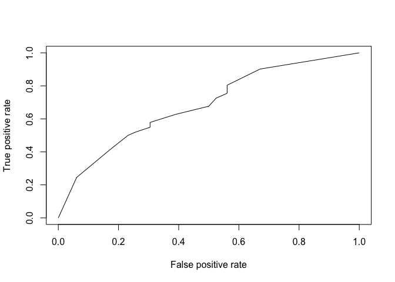

```r
predictcart1_prob <- predict(cart1, newdata = test) # predicted probabilities of rev=0 and rev=1 for each test observation
pred_cart1 <- prediction(predictcart1_prob[,2], test$rev)
perf_cart1 <- performance(pred_cart1, x.measure = "fpr", measure = "tpr")
plot(perf_cart1)
```

```r
performance(pred_cart1, measure = "auc")
```

```
## A performance instance
##   'Area under the ROC curve'
```

In synthesis, we can see that the performance of the logistic regression and CART model are similar.